# DAT561 Final Project

#### NOTE: Please be creative in defining the new variables as part of the data manipulation and write your description at the end of each code as the comment. We will read your logic and description for the assessment.

```python
import pandas as pd
import numpy as np
```

```python
#read the dataset here
pdt = pd.read_csv("Property_details.csv") # Please use your path and dataset for this parts!
odt = pd.read_csv("Order_details.csv")

pdt.shape
```

```
(106193, 11)
```

```python
odt.head()
odt.shape
```

```
(165873, 21)
```

## Question 1

#### Part (a): How many properties are there in the region with the zip code of 84100?

#### Part (b): What is the mean, standard deviation, median, min, and max of “starratings” for all properties in the region with the zip code of 84100?

```python
#(1a)
num_pro = pdt.loc[pdt["zipcode"]==84100,"propertyid"].count()
print(num_pro)
```

```
52
```

```python
#(1b)
sta_summary = pdt.loc[pdt["zipcode"]==84100,"starrating"].describe(percentiles=[.50])

sta_summary.index = ["total count","mean","standard_deviation","min","median","max"]

print("For all properties in the region with the zip code of 84100:")
for i, v in sta_summary.items():
    print("\t The %s of starratings is %0.2f." % (i,v))
```

```
For all properties in the region with the zip code of 84100:
	 The total count of starratings is 52.00.
	 The mean of starratings is 2.85.
	 The standard_deviation of starratings is 0.75.
	 The min of starratings is 2.00.
	 The median of starratings is 3.00.
	 The max of starratings is 4.00.
```

## Question 2

#### Part (a): Create a new column called "weekday", which is the day of the “reservation date” in one week (for example, if the reservation date is 2021/10/22, the corresponding value in the new column "weekday" should be “Friday”).

#### Part (b): Which "weekday" does receive the most reservation?

```python
#(2a)
import datetime
weekday_D = {0: 'Monday',1:'Tuesday',2:'Wednesday',3:'Thursday',4:'Friday',5:'Saturday',6:'Sunday'}

def get_weekday(reservation_date):

    week_index = datetime.datetime.strptime(reservation_date, "%m/%d/%Y").weekday()
    week_day = weekday_D[week_index]
    return week_day

odt["weekday"] = odt["reservation date"].apply(get_weekday)
```

```python
#(2b)
weekday_count = odt["weekday"].value_counts()[:1]

for i, v in weekday_count.items():

    print("%s receive the most reservation, which is %d."%(i,v))
```

```
Thursday receive the most reservation, which is 26589.
```

## Question 3

#### Part (a): In “roomamenities”, what are the top 10 common room amenities? What about the 10 least common room amenities? ( for example, Air conditioning is one amenity)

```python
# You can deceide whether to display you output for 3(a) and 3(b) separately or together
amenities_Dict ={}

for i in odt["roomamenities"]:
    if type(i)==str:
        temp = i.split(": ;")
        for j in temp:
            if len(j)>0:
                if j in amenities_Dict.keys():
                    amenities_Dict[j]+=1
                else:
                    amenities_Dict[j]=1
```

```python
# If you displayed your output of 3(b) together with 3(a) please delete this chunk
top_10 = sorted(amenities_Dict.items(), key=lambda item:item[1],reverse = True)[0:10]

least_10 = sorted(amenities_Dict.items(), key=lambda item:item[1])[0:10]

print("The top 10 are: ")

for i in range(0,10):
    print("\t Top %d: %25s\t %d" %(i+1,top_10[i][0],top_10[i][1]))

print("The least 10 are: ")

for i in range(0,10):
    print("\t Top %d: %25s\t %d" %(i+1,least_10[i][0],least_10[i][1]))
```

```
The top 10 are:
	 Top 1:          Air conditioning	 161054
	 Top 2:          In-room safe box	 161054
	 Top 3:  Free Wi-Fi in all rooms!	 157613
	 Top 4:                Hair dryer	 127316
	 Top 5:                Toiletries	 119993
	 Top 6:                   Heating	 119196
	 Top 7:                      Desk	 114593
	 Top 8:                 Telephone	 113827
	 Top 9:                    Closet	 113368
	 Top 10:                    Towels	 106225
The least 10 are:
	 Top 1:  Open air bath privileges	 12
	 Top 2:                   Hot tub	 13
	 Top 3:           Vending machine	 24
	 Top 4:                Humidifier	 45
	 Top 5:          TV [in bathroom]	 58
	 Top 6:    Internet access ï¿?LAN	 72
	 Top 7:             First aid kit	 98
	 Top 8:              Air purifier	 103
	 Top 9:            In-room tablet	 161
	 Top 10:              Wi-Fi [free]	 196
```

#### Part (b): What percentage does each type of room amenities occupy of the total number of reservations for all properties?（do not use the total number of amenities as denominator）

```python
num_pro = odt["id"].count()

percentage_Dict = {}

for i,j in amenities_Dict.items():
    percentage_Dict[i] = j/num_pro

percentage_Dict
```

```
{'Air conditioning': 0.9709476527222635,
 'Alarm clock': 0.2408830852519699,
 'Carpeting': 0.4291777444189229,
 'Closet': 0.6834626491351817,
 'Coffee/tea maker': 0.47374798791846773,
 'Desk': 0.6908478173060112,
 'DVD/CD player': 0.04058526704165235,
 'Fan': 0.12297360028455505,
 'Free Wi-Fi in all rooms!': 0.9502028660481211,
 'Hair dryer': 0.7675510782345529,
 'Heating': 0.7185979635021975,
 'In-room safe box': 0.9709476527222635,
 'Ironing facilities': 0.4158422407504537,
 'Linens': 0.4673334418500901,
 'Mini bar': 0.31153955134349776,
 'Seating area': 0.25572576609815945,
 'Toiletries': 0.7234028443447698,
 'Towels': 0.6403995828133572,
 'TV [flat screen]': 0.16884604486565022,
 'Fireplace': 0.010767273757633852,
 'Full kitchen': 0.022782490218420118,
 'High chair': 0.025899332621945704,
 'Microwave': 0.040326032567084454,
 'Separate dining area': 0.05918986212343178,
 'Sofa': 0.1663501594593454,
 'TV': 0.18449657267909786,
 'Washing machine': 0.011912728412701284,
 'Dishwasher': 0.014251867392523196,
 'Refrigerator': 0.1842915965829279,
 'Clothes rack': 0.29844519602346375,
 'Daily housekeeping': 0.1970001145454655,
 'Internet access �?wireless': 0.0034122491303587685,
 'Satellite/cable channels': 0.6176050351775153,
 'Telephone': 0.6862298264334762,
 'On-demand movies': 0.0955791479023108,
 'Wake-up service': 0.5445973726887438,
 'Wooden/parqueted flooring': 0.14598518143398864,
 'Bathrobes': 0.1823985820477112,
 'Free bottled water': 0.26669801595196324,
 'Laptop safe box': 0.13758116149102023,
```

[output cut: 36 more lines]

```
 'Scale': 0.002146220301073713,
 'Wi-Fi [charges apply]': 0.0021281341749410693,
 'Air purifier': 0.0006209569972207653,
 'Carbon monoxide detector': 0.0014710049254550168,
 'Bathroom phone': 0.005582584266276006,
 'Video game console': 0.008892345348549794,
 'Hot tub': 7.837321324145581e-05,
 'Humidifier': 0.0002712918919896547,
 'Free welcome drink': 0.004497416698317387,
 'Wi-Fi [free]': 0.0011816269073327184,
 'First aid kit': 0.0005908134536663592,
 'Vending machine': 0.0001446890090611492,
 'TV [in bathroom]': 0.00034966510523111054,
 'Internet access �?LAN': 0.00043406702718344755,
 'Open air bath privileges': 7.23445045305746e-05}
```

## Question 4

#### Part (a): For each property, there are some abnormal values of 0 in the “onsiteprice”. To better organize the data, you would like to create a new column “replaced onsiteprice” in the dataset by retaining the original non-zero “onsiteprice” of one specific property and replacing the zero value with its median of non-zero “onsiteprice”.

#### Part (b): For each property, calculate the maximum and minimum value of “replaced onsiteprice”, and store these two into corresponding two columns named “Maximum” and “Minimum”. Then create a column named “Normalized Maximum” to store the normalized form of the “Maximum” column. You can use the formula below for the normalization (do not round the result). Store the “hotelcode”, “Maximum”, “Minimum”, “Normalized Maximum” to "Mx_Min Price.csv".

$$ X_{norm} = \frac{X-X_{min}}{X_\max-X_{min}}$$

```python
#4(a)
median_price = odt["onsiteprice"].loc[odt["onsiteprice"]!=0].median()
new_price = odt["onsiteprice"].copy()
odt["replaced_onsiteprice"] = new_price
odt["replaced_onsiteprice"]=odt["replaced_onsiteprice"].replace(0,median_price)
odt.head()
```

|  | id | propertycode | dtcollected | reservation date | los | guests | roomtype | onsiteprice | ratedescription | ratetype | ... | ispromo | closed | discount | promoname | proxyused | mealinclusiontype | hotelblock | input_dtcollected | weekday | replaced_onsiteprice |
| --- | --- | --- | --- | --- | --- | --- | --- | --- | --- | --- | --- | --- | --- | --- | --- | --- | --- | --- | --- | --- | --- |
| 0 | 50677497 | 634876 | 10/12/2019 15:46 | 11/2/2019 | 1 | 1 | Double Room | 82.36 | Room size: 15 m²/161 ft², Shower, 1 king bed | Cancellation policy | ... | Y | N | 6.24 | NaN | media:M3diAproxy@173.44.165.126:80 | Free Breakfast | NaN | 10/13/2019 | Saturday | 82.36 |
| 1 | 50672149 | 8328096 | 10/12/2019 15:47 | 11/30/2019 | 1 | 1 | Vacation Home | 636.09 | Shower, Kitchenette, 2 bedrooms, 1 double bed ... | Cancellation policy | ... | N | N | 0.00 | NaN | media:M3diAproxy@173.44.164.126:80 | NaN | NaN | 10/13/2019 | Saturday | 636.09 |
| 2 | 50643430 | 8323442 | 10/12/2019 15:47 | 12/20/2019 | 1 | 1 | Vacation Home | 591.74 | Shower, Kitchenette, 2 bedrooms, 1 double bed ... | Extra low price! (non-refundable) | ... | N | N | 0.00 | NaN | media:M3diAproxy@173.44.166.122:80 | NaN | NaN | 10/13/2019 | Friday | 591.74 |
| 3 | 50650317 | 7975 | 10/12/2019 15:47 | 12/28/2019 | 1 | 1 | Standard Triple Room | 881.48 | Room size: 20 m²/215 ft², Shower, 3 single beds | Extra low price! (non-refundable) | ... | N | N | 0.00 | NaN | media:M3diAproxy@209.242.219.141:80 | NaN | NaN | 10/13/2019 | Saturday | 881.48 |
| 4 | 50650318 | 7975 | 10/12/2019 15:47 | 12/28/2019 | 1 | 1 | Standard Triple Room | 897.53 | Room size: 20 m²/215 ft², Shower, 3 single beds | Extra low price! (non-refundable) | ... | N | N | 0.00 | NaN | media:M3diAproxy@209.242.219.141:80 | Free breakfast for {3} | NaN | 10/13/2019 | Saturday | 897.53 |

5 rows × 23 columns

```python
#4(b)
! pip install pandasql
from pandasql import sqldf

df_sql1 = sqldf("SELECT propertycode AS hotelcode,max(replaced_onsiteprice) AS Maximum,\
min(replaced_onsiteprice) AS Minimum FROM odt GROUP BY propertycode")

mini = df_sql1["Maximum"].min()

maxi= df_sql1["Maximum"].max()

df_sql1["Normalized Maximum"] = (df_sql1["Maximum"]-mini)/(maxi-mini)

df_sql1.to_csv("Mx_Min Price.csv")
```

## Question 5

#### Part (a): A family of three is planning a trip. How many available hotels do offer a room with the “maxoccupancy” of 3 or more? Available hotel are those whose “propertype” are “Hotels”, “close” are “N”, and “hotelblock” are not “sold out” .

#### Part (b): If this family does not want to pay a room for a “replaced onsiteprice” higher than 150 per night, how many hotels are still available? Use the maximum of “replaced onsiteprice” to compare with 150 due to price fluctuation.

```python
#5(a)

Property_result = pd.merge(pdt,odt,left_on='propertyid', right_on='propertycode', how = 'left')

index_x = (Property_result['propertytype'] == 'Hotels')&(Property_result['closed'] == 'N')&(Property_result['hotelblock']!='sold out')&(Property_result['maxoccupancy']>=3)

Available_hotel_a = Property_result[index_x]['propertyid'].unique()

print(f'{len(Available_hotel_a)} hotels are still available')
```

```
3085 hotels are still available
```

```python
#5(b)
price_max = Property_result[index_x].groupby('propertyid',as_index=False)['replaced_onsiteprice'].max()

Available_hotel_b = price_max[price_max['replaced_onsiteprice']<=150]['propertyid'].unique()

print(f'higher than 150 per night,{len(Available_hotel_b)} hotels are still available')
```

```
higher than 150 per night,1453 hotels are still available
```

## Bonus Question (merge data, filter, groupby, merge three times)

#### Part (a): For each country, find the most expensive property by using “replaced onsiteprice”. Provide id, name, city, country, zip code, address, and average “replaced onsiteprice” of these properties.

#### Part (b): For each country, find the cheapest property by using “replaced onsiteprice”. Provide id, name, city, country, zip code, address, and average “replaced onsiteprice” of these properties.

#### Hint: Each country has numbers of hotels, and each hotel has numbers of prices due to price fluctuation. You need to find the average “replaced onsiteprice” for each hotel first, and sort out the cheapest and the most expensive hotels then.

```python
# use merge and groupby function to make a dataframe
Property_result2 = pdt.merge(odt, left_on='propertyid', right_on='propertycode', how = 'left')
Property_result2 = Property_result2.groupby(["propertyid","propertyname","city","country","zipcode","address"])["replaced_onsiteprice"].mean().reset_index()
country_set = set(Property_result2["country"])
```

```python
#(a)
Property_result3 = pd.DataFrame()
for country in country_set:
    temp = Property_result2[Property_result2["country"]==country].sort_values("replaced_onsiteprice",ascending=False).head(1)
    Property_result3 = pd.concat([Property_result3,temp],axis=0)

Property_result3.reset_index().drop("index",axis=1)
```

|  | propertyid | propertyname | city | country | zipcode | address | replaced_onsiteprice |
| --- | --- | --- | --- | --- | --- | --- | --- |
| 0 | 49541 | Hotel Roosendaelhof | Geel | Belgium | 2440.0 | Stationsstraat 50 | 403.902979 |
| 1 | 2729537 | Hotel Sava | Rogaska Slatina | Slovenia | 3250.0 | Zdraviliski trg 6 | 224.951043 |
| 2 | 365601 | HavsVidden Resort | Geta | Finland | 22340.0 | Havsviddsvagen 90 | 512.370000 |
| 3 | 788156 | Hilton Garden Inn Krakow Airport | Balice | Poland | 32083.0 | Kapitana Mieczyslawa Medweckiego 3 | 141.314133 |
| 4 | 6986740 | Locanda Ca'Lucrezia | Venice | Italy | 30121.0 | Cannaregio Calle Priuli dei Cavaletti 76, | 1123.194474 |
| 5 | 1086096 | St. Elias Resort | Protaras | Cyprus | 5296.0 | 44 st elias street | 266.771923 |
| 6 | 2676915 | Hyatt Place Farmington | Farmington | United Kingdom | 84014.0 | 222 NORTH UNION AVENUE | 145.156048 |
| 7 | 118921 | Hotel Parc Beaux Arts | Luxembourg | Luxembourg | 2536.0 | 1 Rue Sigefroi | 285.215000 |
| 8 | 325384 | Apartmanovy Dom TatraTravel Smokovec | Vysoke Tatry | Slovakia | 6201.0 | Novy Smokovec 72 | 234.076667 |
| 9 | 3015005 | Theodora Golf Club | Alba Iulia | Romania | 517246.0 | Str. Principala, Nr. 75C | 167.495000 |
| 10 | 162478 | Quality Hotel and Leisure Centre Clonakilty | Clonakilty | Ireland | 0.0 | Skibbereen Road | 97.163000 |
| 11 | 2081988 | Golden Tulip Braga Hotel & Spa | Braga | Portugal | 4715.0 | N309 | 76.790769 |
| 12 | 7503033 | Aspen Golf and Ski Resort | Razlog | Bulgaria | 2760.0 | Betolovoto Aspen Golf | 1072.850000 |
| 13 | 112561 | Hotel Marmont - Adults Only | Split | Croatia | 21000.0 | Zadarska 13 | 920.066216 |
| 14 | 6582086 | Hotel Munich City | Munich | Germany | 80339.0 | Schwanthalerstrasse | 1264.736111 |
| 15 | 8651540 | Soho Boutique Colon | Malaga | Spain | 29001.0 | 5 Alameda Colon | 1072.585000 |
| 16 | 5925673 | Slottsholmen, BW Premier Collection | Vastervik | Sweden | 59338.0 | Slottsholmsvagen 10 | 242.385000 |
| 17 | 6720987 | Copenhagen Island Hotel | Copenhagen | Denmark | 1560.0 | Kalvebod Brygge 53 | 228.724522 |
| 18 | 239165 | Anatolia Hotel | Mykonos | Greece | 84600.0 | Ano Mera | 4795.000000 |
| 19 | 130055 | Superior Alpine Wellnesshotel Karwendel | Pertisau | Austria | 6213.0 | Nr. 54a | 655.020000 |
| 20 | 442720 | Hotel Astrid | Lourdes | France | 65100.0 | Place Merlasse | 5739.627500 |
| 21 | 367192 | Hotel Bila Ruze | Strakonice | Czech Republic | 38601.0 | Palackeho Namesti 80 | 676.515714 |
| 22 | 274319 | Palma Panzio Kaposvar | Kaposvar | Hungary | 7400.0 | Szechenyi square 6 | 3231.450000 |
| 23 | 96946 | Hotel Sint Nicolaas | Amsterdam | Netherlands | 1012.0 | Spuistraat 1a | 222.148707 |
| 24 | 392207 | Chalet Mont Bijou | Veysonnaz | Switzerland | 1993.0 | Salins | 623.390000 |
| 25 | 91162 | Astra Hotel | Sliema | Malta | 1605.0 | 127 Graham Street | NaN |
| 26 | 2202 | Radisson Blu Sky Hotel Tallinn | Tallinn | Estonia | 10143.0 | Ravala Street 3 | 193.730909 |
| 27 | 6571466 | Hotel Jurmala Spa | Jurmala | Latvia | 2015.0 | Jomas iela | 100.134000 |
| 28 | 2574564 | Artagonist hotel | Vilnius | Lithuania | 1123.0 | Pilies str. 34 | 206.705000 |

```python
#(b)
Property_result4 = pd.DataFrame()

for country in country_set:
    temp = Property_result2[Property_result2["country"]==country].sort_values("replaced_onsiteprice",ascending=True).head(1)
    Property_result4 = pd.concat([Property_result4,temp],axis=0)

Property_result4.reset_index().drop("index",axis=1)
```

|  | propertyid | propertyname | city | country | zipcode | address | replaced_onsiteprice |
| --- | --- | --- | --- | --- | --- | --- | --- |
| 0 | 4846208 | ibis budget Blankenberge | Blankenberge | Belgium | 8370.0 | Kerkstraat 120 | 55.612857 |
| 1 | 5913415 | Gostisce Kimovec | Litija | Slovenia | 1270.0 | Zgornji Hotic 15 | 40.370000 |
| 2 | 887106 | Kempeleen Moottorimaja | Kempele | Finland | 90440.0 | Sohjanantie 3 | 51.378571 |
| 3 | 471814 | Mela Verde | Zakret | Poland | 28246.0 | ul. Cisowa 1 | 66.159000 |
| 4 | 7083537 | L' Isola della Fanciulla | Salve | Italy | 73050.0 | Corso Colombo, 3 | 27.186667 |
| 5 | 184567 | Bellapais Monastery Village | Ozankoy | Cyprus | 9944.0 | Bellapais Yolu Girne | 35.880769 |
| 6 | 5104595 | STAYBRIDGE SUITES LONDON-HEATHROW BATH ROAD | London | United Kingdom | 430033.0 | 276A BATH ROAD WEST DRAYTON | 122.264545 |
| 7 | 158021 | Le Petit Poete | Echternach | Luxembourg | 6460.0 | Place Du Marche 13 | 100.320000 |
| 8 | 490773 | Hotel Premier | Trnava | Slovakia | 91701.0 | Haulikova 4 | 48.223333 |
| 9 | 1966150 | Hanul cu Flori | Braila | Romania | 810077.0 | Soseaua Focsani, Km 5 | 11.800000 |
| 10 | 162478 | Quality Hotel and Leisure Centre Clonakilty | Clonakilty | Ireland | 0.0 | Skibbereen Road | 97.163000 |
| 11 | 119935 | Comfort Inn Braga | Braga | Portugal | 4700.0 | EN 14 Ferreiros Rua | 53.585556 |
| 12 | 449128 | Family Hotel Natalis | Hisarya | Bulgaria | 4180.0 | 20 Geo Milev Str. | 18.826667 |
| 13 | 1177961 | The Movie Hotel Zagreb | Zagreb | Croatia | 10000.0 | Savska cesta | 41.282000 |
| 14 | 115079 | Hotel Adam | Berlin | Germany | 10627.0 | Kaiser-Friedrich-Strasse 51 | 44.400000 |
| 15 | 67687 | N.Ch | Torremolinos | Spain | 29620.0 | Plaza de la Gamba Alegre, 5 | 36.080909 |
| 16 | 237679 | Clarion Collection Hotel Bristol | Arvika | Sweden | 67131.0 | Kyrkogatan 25 | 69.970972 |
| 17 | 6629907 | Zleep Hotel Aarhus Nord | Aarhus | Denmark | 8200.0 | Tangen 45 | 58.844000 |
| 18 | 5302869 | Mirtia Hotel | Pefki (Artemisio) | Greece | 34200.0 | Pefki | 28.477500 |
| 19 | 6537481 | Dolomitenhotel | Lienz | Austria | 9900.0 | 2 Dolomitenstrasse | 12.060000 |
| 20 | 7600445 | Studio Moncoeur | Le Blanc | France | 36300.0 | 31 Rue du Docteur Fardeau | 33.150000 |
| 21 | 390933 | Hotel Praded Jesenik | Jesenik | Czech Republic | 79001.0 | Dukelska 178 | 14.800000 |
| 22 | 454523 | Hotel Fama | Hodmezovasarhely | Hungary | 6800.0 | Szeremlei utca 7. | 26.268000 |
| 23 | 344180 | Best Western Plus Amsterdam Airport | Amsterdam | Netherlands | 2132.0 | Vuursteen 1 | 103.562778 |
| 24 | 183217 | Chesa Valese | Zermatt | Switzerland | 3920.0 | Steinmattstrasse 30 | 48.665000 |
| 25 | 91162 | Astra Hotel | Sliema | Malta | 1605.0 | 127 Graham Street | NaN |
| 26 | 7621602 | ibis Tallinn Center | Tallinn | Estonia | 10132.0 | Juhkentali 28 | 84.365714 |
| 27 | 6571466 | Hotel Jurmala Spa | Jurmala | Latvia | 2015.0 | Jomas iela | 100.134000 |
| 28 | 7796793 | Puntukas | Kuciai | Lithuania | 29132.0 | 15 A. Baranausko aikste | 51.110000 |

## Part 2 (9 Points):

For this part, we look at the logic and how you solve the problems.

*Part 2-a:*

```
1- You need to find "5" interesting business questions based on the datasets.
2- Write Python code to answer the questions.
3- Visualize your results.
```

*Part 2-b:*

```
Write a 300-word summary of your answers and business insights you get from answering these 5 questions based on your code. Ensure that you have clearly explained why we should care about your questions and your results. Clearly explain your findings.
```

*This part will be evaluated based on the following criteria:*

```
1. You need to ask five business-relevant questions. (2 points)
2. You need to answer these five questions using Python and the datasets. (2 points)
3. You need to have at least "5" graphs to visualize your insights. (2 points)
4. Your executive summary of your answers is well-written and makes sense. (2 points)
5. Your business insights are very interesting and the report is creative. (1 points)
```

**(You need to use this cell to write your 5 questions)**

**Question 1:** What time of the 4 months should customers avoid hotel stays by rate?

**Question 2:** What time of the 4 months should customers avoid hotel stays by hotel block?

**Question 3:** What is the avergae room rate by hotel star-rating?

**Question 4:** What is the most popular room type?

**Question 5:** When is the best time to book the most popular rooom type?

```python
# Your code to answer Question 1
def datetomonth (date):
    month = date.split('/')[0]
    return int(month)

#datetomonth(odt["reservation date"][0])

odt["month"] = odt["reservation date"].apply(datetomonth)
odt.groupby("month").mean()["onsiteprice"].sort_values()
```

```
month
10    134.368651
11    136.620532
1     137.619641
12    143.327347
Name: onsiteprice, dtype: float64
```

```
[Text(0, 0.5, '4 months should customers avoid '),
```

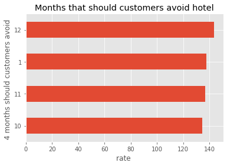

```python
#Add the plot
Graph1 = odt.groupby("month").mean()["onsiteprice"].sort_values()

import matplotlib.pyplot as plt

plt.style.use("ggplot")
fig,ax0 = plt.subplots(nrows=1,ncols=1,sharey = True) #sharey / sharex share the axis

Graph1.plot(kind = "barh", y="onsiteprice", x = "month", ax=ax0)

ax0.set(ylabel = "4 months should customers avoid ", xlabel = "rate ", title = "Months that should customers avoid hotel")
```

```python
# Your code to answer Question 2
block_num = odt.groupby("month").count()
(block_num["hotelblock"]/block_num["id"]).sort_values()
```

```
month
12    0.024630
1     0.025806
11    0.027599
10    0.041734
dtype: float64
```

```
[Text(0, 0.5, '4 months should customers avoid '),
```

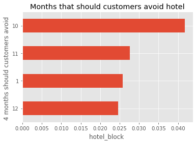

```python
import matplotlib.pyplot as plt

plt.style.use("ggplot")
fig,ax1 = plt.subplots(nrows=1,ncols=1,sharey = True) #sharey / sharex share the axis
Graph2 = (block_num["hotelblock"]/block_num["id"]).sort_values()
Graph2.plot(kind = "barh", y="onsiteprice", x = "month", ax=ax1)

ax1.set(ylabel = "4 months should customers avoid ", xlabel = "hotel_block ", title = "Months that should customers avoid hotel")
```

```python
# Your code to answer Question 3
table = pd.merge(odt, pdt, left_on = "propertycode", right_on = "propertyid")
table.groupby("starrating").mean()["onsiteprice"]
```

```
starrating
2     86.047741
3    112.372343
4    168.592808
Name: onsiteprice, dtype: float64
```

```
[Text(0, 0.5, 'star rating '),
```

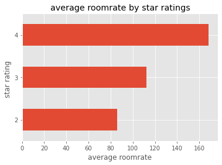

```python
import matplotlib.pyplot as plt
table = pd.merge(odt, pdt, left_on = "propertycode", right_on = "propertyid")
Graph3 = table.groupby("starrating").mean()["onsiteprice"]
plt.style.use("ggplot")
fig,ax2= plt.subplots(nrows=1,ncols=1,sharey = True) #sharey / sharex share the axis

Graph3.plot(kind = "barh", y="onsiteprice", x = "starrating", ax=ax2)

ax2.set(ylabel = "star rating ", xlabel = "average roomrate", title = "average roomrate by star ratings")
```

```python
# Your code to answer Question 4
odt.groupby("roomtype").count().sort_values("id", ascending = False)["id"].head()
```

```
roomtype
Double Room             8227
Twin Room               4459
Single Room             4260
Standard Double Room    4151
Triple Room             3705
Name: id, dtype: int64
```

```
[Text(0, 0.5, 'room type '),
```

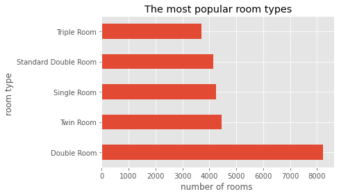

```python
import matplotlib.pyplot as plt

plt.style.use("ggplot")
fig,ax3 = plt.subplots(nrows=1,ncols=1,sharey = True) #sharey / sharex share the axis
Graph4 = odt.groupby("roomtype").count().sort_values("id", ascending = False)["id"].head()
Graph4.plot(kind = "barh", y="onsiteprice", x = "month", ax=ax3)

ax3.set(ylabel = "room type ", xlabel = "number of rooms ", title = "The most popular room types")
```

```python
# Your code to answer Question 5
table[table["roomtype"] == "Double Room"].groupby("month").mean()["onsiteprice"].sort_values()
```

```
month
10    89.477625
11    90.108713
1     99.076512
12    99.456006
Name: onsiteprice, dtype: float64
```

```
[Text(0, 0.5, 'Best time(month) '),
```

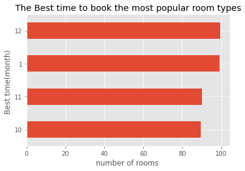

```python
import matplotlib.pyplot as plt

plt.style.use("ggplot")
fig,ax4 = plt.subplots(nrows=1,ncols=1,sharey = True) #sharey / sharex share the axis
Graph5 = table[table["roomtype"] == "Double Room"].groupby("month").mean()["onsiteprice"].sort_values()
Graph5.plot(kind = "barh", y="onsiteprice", x = "month", ax=ax4)

ax4.set(ylabel = "Best time(month) ", xlabel = "number of rooms ", title = "The Best time to book the most popular room types")
```

## Executive Summary & Business insights:

**(You need to use the cell below to write your executive summary & business insights)** Note: If you need more space use enter to go to the next line.

Our team aim to provide recommendation of hotel selection for customers to help them find out how to book a hotel in a cheaper way.  
First, we design question 1 and 2 to see the most two risky months in terms of pricing and proportion of block. According to result of question 1 and 2, December has the highest average on-site price and October has the highest sold-out rate. We conclude that customers should avoid booking hotels in December and book October earlier in case rooms are sold out.  
Next, question 3 provides insight of the positive relationship between hotel star rating and room price: as the star rating goes higher, room rating becomes higher. By comparing the current price with the average room rate, customers could choose a relatively cheaper hotel by hotel type.  
Question 4 asks the most popular room type to help customers learn which room would sell fast. Double room is the most popular room type as shown in the result, which indicates that customers who travel alone or with one companion should preserve double room in advance.  
Finally, question 5 is designed to see which the cheapest month is to book the double room in a hotel. We learned that October has the lowest double room rate among four months, while January and December are almost equally expensive.  
In general, we recommend that October is the best time to book a hotel stay, and December is the worst in terms of saving money. However, customers should be careful to risk of hotel block and make reservation earlier.

PART 1 - Question Points: 1a - 2 points; 1b - 1 point; 2a - 3 points; 2b - 2 points; 3a - 3 points; 3b - 1 point; 4a - 3 points; 4b - 4 points; 5a - 3 points; 5b - 3 points; Bonus(a) - 1 point; Bonus(b) - 1 point;

PART 2 - 9 points total

Good Luck!